# Individual vs. General Semantic Analyses

Kyra Brown

2026-10-13

```r
library(tidyverse)
library(ggrepel) #for label pushing apart
library(lme4) #for fitting linear mixed models
library(lmerTest) #modifies lmer to print summary
```

```r
library(patchwork) #combined ggplots in one figure
library(performance) #diagnostics models
library(here) #file paths relative to project root
library(tools)
library(stringi) #string operations

here::i_am("Analysis/IndvSemanticAnalysis.Rmd") #situates project within github repo
```

```
## here() starts at /Users/kbrown3/Library/CloudStorage/OneDrive-BowdoinCollege/Documents/GitHub/fluency-individual-variance
```

# reading matrices

To begin the analysis, matricies for each participant are loaded in from the google drive and stored in r’s memory to prevent repeated downloading. This resulted in a total of 109 matricies with the dimensions 3080 x 3080

```r
# Read the file listing
rds_path <- here("Data", "similarity_matricies.rds")

if(file.exists(rds_path)) {
  matrix_list <- readRDS(rds_path) #reads list of matricies back into memory instead of redownloading if it exists
} else {
  files <- read_csv(here("Data", "similarity_files.csv"), show_col_types = FALSE)

  matrix_list <- setNames(
  map(files$id, function(id) {
    url <- paste0("https://drive.usercontent.google.com/download?id=",
      id,"&export=download&confirm=t")
    as.matrix(read.table(url, header = FALSE))
    }),
  toupper(file_path_sans_ext(files$name))
  )
  saveRDS(matrix_list, rds_path)
}

# Check the column names and first few rows
# head(files)

# Number of matrices loaded
length(matrix_list)
```

```
## [1] 109
```

```r
# Participant IDs
names(matrix_list)
```

```
##   [1] "0GMT2ITP" "00K73X1D" "0L28O7LJ" "0MGC7F4K" "0PRAW6DO" "0QPSDFM3"
##   [7] "1KEVYYJ9" "2BD455O0" "3YX63NZD" "4CA4DFWP" "5K82MZW1" "6CDVQX7L"
##  [13] "6D26ZXC8" "6PJDUW9O" "6VBV95IL" "6XD6NVVO" "7SUXPU9Y" "8BL6X7AX"
##  [19] "8JEQ20SU" "8PAKX1OM" "8ZC5BFHF" "9KZ4Q91O" "9O2ABUMY" "18HXK612"
##  [25] "20ISZCV2" "37UDZTHY" "40SNDKQR" "56M8U5A5" "64LRAXDJ" "73N2RQWR"
##  [31] "86EKSDZC" "97N7CQ49" "476LZI3N" "A5YUTA1F" "AJVNZ9CE" "AWO2EA8Q"
##  [37] "B3MZX5TF" "BF3MN8ZR" "BWQ1ZSYD" "CI6QQA2Y" "DUBYYHYX" "EA8GWQDV"
##  [43] "ESNMRF10" "FDULT82W" "FJYUEQN8" "FYE2JV3H" "G8B6AJJV" "GNLFFB4P"
##  [49] "H6D2C4VR" "HCBTBYHS" "HZP27937" "IEOJ1IW3" "IN92PH3J" "IRFHWRXF"
##  [55] "J8N7DCDH" "JDVDZARM" "JEW0DH9D" "JIMIPV7S" "K6LTYZJH" "KMXD4OZC"
##  [61] "KZ9S5MPC" "LJSMGNV0" "LN8REBYY" "LUKGQM9Q" "MCYP84X4" "N9V0QKO1"
##  [67] "NHCBLFL1" "NRXHKYAS" "NXGNLGFN" "NZ8ZTZHG" "O4NB1X6B" "OEQ7A3BW"
##  [73] "OUSZQD8K" "OX30M9NX" "PBNU471N" "PLC36LSR" "PLW1S0CA" "Q3MFUDV9"
##  [79] "QGT05169" "RLHDN7YZ" "RS0Z27EB" "S30LA614" "S87Q76NA" "SENRROOG"
##  [85] "T6E9EPOZ" "TPWBA9PZ" "U2N1A8VX" "U7RW6MVC" "UIBPJL1Q" "UVAI5SO9"
##  [91] "VJJ2VCIY" "VNHTSXTP" "VNSY2V6A" "W6Z3Y3K6" "WU4Q5VLP" "XAA8CS8F"
##  [97] "XI93MR3J" "XILQXDX5" "XJF7RLTQ" "XV9JV4CP" "Y0GQPG0K" "YDKEN7JY"
## [103] "YMQ1DC06" "YP5UHRSA" "YQ5FHGIU" "YVQX6LL1" "ZERL6DH6" "ZHMH16C4"
## [109] "ZYQ1C8LT"
```

```r
# Dimensions of the first matrix
dim(matrix_list[[1]])
```

```
## [1] 3080 3080
```

```r
# Inspect the first matrix
matrix_list[[1]][1:5, 1:5]
```

```
##                V1         V2         V3           V4         V5
## [1,] 0.000000e+00 0.01330582 0.03026633 7.920441e-05 0.05189772
## [2,] 1.330582e-02 0.00000000 0.03069206 1.620250e-02 0.02878547
## [3,] 3.026633e-02 0.03069206 0.00000000 6.755480e-02 0.01058265
## [4,] 7.920441e-05 0.01620250 0.06755480 0.000000e+00 0.13826334
## [5,] 5.189772e-02 0.02878547 0.01058265 1.382633e-01 0.00000000
```

```r
# Check dimensions across all matrices
dims <- vapply(matrix_list,
               function(m) paste(dim(m), collapse = " x "),
               character(1))

table(dims)
```

```
## dims
## 3080 x 3080
##         109
```

```r
# saveRDS(matrix_list, file = "similarity_matrices.rds")
# for future
# matrix_list <- readRDS("similarity_matrices.rds")
```

## Reading in files with global paths

```r
word_file <- here("Data", "kumar_fluencyWords.txt") #path to word list used in fluency/matricies
data_location <- here("Data")
output_location <- here("Analysis", "forager", "output")
domains <- c("animals","authors", "college_majors", "musicians", "sportspersons")
```

## Data Preprocessing

Prior to analysis steps, fluency data was imported and, in accordance with preprocessing, all participants producing less than four responses in any category or lacking a matrix, participant U4TQC9J3, were removed from data sets and further analysis.

```r
#reads in fluency data and ensures subject col is text data
fluency_data <- read_csv(here("Data", "cleaned_data", "fluency_data.csv"), show_col_types = FALSE) %>%
  mutate(Subject = as.character(Subject))

#participants producing less than four responses in any category discovered and pulled
fluency_number <- fluency_data %>%
  group_by(Subject, domain) %>%
  summarise(item_count = n(), .groups = "drop")

#stores subjects who produced less than four responses
low_response_subjects <- fluency_number %>%
  filter(item_count < 4) %>%
  pull(Subject) %>%
  unique()

#stores subjects whos ID is not in the matrix names
no_matrix_subjects <- fluency_data %>%
  filter(!Subject %in% low_response_subjects) %>%
  pull(Subject) %>%
  unique() %>%
  .[!toupper(.) %in% names(matrix_list)]

no_matrix_subjects
```

```
## [1] "U4TQC9J3"
```

```r
#the pulled participants are filtered out of all defined data sets
excluded_subjects <- unique(c(low_response_subjects, no_matrix_subjects))


fluency_data <- fluency_data %>%
  filter(!Subject %in% excluded_subjects)
```

##Cleaning word list

```r
#reading in the fluency word list into a vector, trims spaces/tabs, drops empty lines, creates position vector labeling numbers with corresponding word
words <- read_lines(word_file)
words <- trimws(words)
words <- words[nzchar(words)]

stopifnot(all(vapply(matrix_list, function(m) all(dim(m) == length(words)), logical(1)))) #checks column + row number is equal to the word number

word_index <- setNames(seq_along(words), words)
```

##Helper functions

```r
#Builds tibble recording how many rows a filtering step removed and what percent remained
audit_rows <- function(label, before, after) {
  tibble(step = label,
         rows_before = nrow(before),
         rows_after = nrow(after),
         rows_lost = nrow(before) - nrow(after),
         percent_kept = round(100 * nrow(after) / nrow(before), 1))
}

#Pulls columns, flags missing values, and counts them
na_report <- function(df, cols) {
  tibble(column = cols,
         num_na = map_int(cols, ~ sum(is.na(df[[.x]]))),
         percent_na = round(100 * num_na / nrow(df), 1))
}

#The first form of word matching, converting to lowercase and removing white space
normalize_word <- function(x) {
  x %>% str_to_lower() %>% str_remove_all("\\s+")
}

#The second form of word matching, stripping accents, making lowercase, and deleting anything that isn't a letter or number
strip_word <- function(x) {
  x %>% stri_trans_general("Latin-ASCII") %>% str_to_lower() %>%
    str_remove_all("[^a-z0-9]")
}
```

##Pairwise Similarity and Domain Processing

```r
#rebuilds the word index with normalized words
word_index <- setNames(seq_along(words), normalize_word(words))

stripped_index <- setNames(seq_along(words), strip_word(words))
stripped_index <- stripped_index[!duplicated(names(stripped_index))]

#corrects words based on first normalization, if failed tries with the second strip then returns matrix positions
lookup_word <- function(x) {
  i <- unname(word_index[normalize_word(x)])
  miss <- is.na(i)
  i[miss] <- unname(stripped_index[strip_word(x[miss])])
  i
}

#looks up matrix position of both previous words and current words and marks which pairs have both items present
add_pairwise_similarity <- function(group, sim, word_index) {
  group$Previous_Fluency_Item <- lag(group$Fluency_Item) #lag shifts vector down one row so each row has word before it, creating pair
  previous_index <- lookup_word(group$Previous_Fluency_Item)
  current_index <- lookup_word(group$Fluency_Item)
  group$previous_idx <- previous_index
  group$current_idx <- current_index #gives row and column numbers for two words in pair for permutation analysis
  ok <- !is.na(previous_index) & !is.na(current_index)

  #creates column filled with NA then fills valid positions
  group$Pairwise_Indv_Similarity <- NA_real_
  group$Pairwise_Indv_Similarity[ok] <- sim[cbind(previous_index[ok], current_index[ok])]
  group
}

#reads in the forager output of a domain, standardizes name and adds domain label. Then splits the data into per participant data frames and finds the participants matrix and adds similarity column
process_domain <- function(domain) {
  path <- file.path(output_location, paste0(domain, "_forager_results"), "lexical_results.csv")
  if(!file.exists(path)) {message("No lexical results for ", domain); return(NULL)}

  read_csv(path, show_col_types = FALSE) %>%
    rename(subject = Subject) %>%
    mutate(subject = as.character(subject), domain = domain) %>%
    filter(!subject %in% excluded_subjects) %>%
    group_split(subject) %>%
    map(function(g) {
      sim <- matrix_list[[toupper(g$subject[1])]]
      if (is.null(sim)) {message("No matrix for ", g$subject[1]); return(NULL)}
      add_pairwise_similarity(g, sim, word_index)
    }) %>%
    bind_rows()
}

#returns (1) total row #, count of how many items were the first, lacking a previous word, and how many pairs are missing a word from word list, (2) the number of pairs per domain, how many have NA individual similarity cols, and (3) a per domain individual pairwise similarity file
complete_similarities <- map_dfr(domains, process_domain)

complete_similarities %>%
  summarise(
    total = n(),
    first_item = sum(is.na(Previous_Fluency_Item)),
    not_in_word_list = sum(!is.na(Previous_Fluency_Item) &
                             (is.na(lookup_word(Fluency_Item)) | is.na(lookup_word(Previous_Fluency_Item)))))
```

```
## # A tibble: 1 × 3
##   total first_item not_in_word_list
##   <int>      <int>            <int>
## 1  5078        410               27
```

```r
complete_similarities %>%
  filter(!is.na(Previous_Fluency_Item)) %>%
  group_by(domain) %>%
  summarise(pairs = n(),
            missing = sum(is.na(Pairwise_Indv_Similarity)),
            pct_missing = round(100 * missing / pairs, 1))
```

```
## # A tibble: 5 × 4
##   domain         pairs missing pct_missing
##   <chr>          <int>   <int>       <dbl>
## 1 animals         1732       6         0.3
## 2 authors          393       1         0.3
## 3 college_majors  1240       0         0
## 4 musicians        752       9         1.2
## 5 sportspersons    551      11         2
```

```r
complete_similarities %>%
  group_split(domain) %>%
  walk(function(d) {
    write_csv(d %>% rename(Subject = subject) %>% select(-domain),
              file.path(output_location, paste0(d$domain[1], "_forager_results"), "lexical_results_indv_pairwise_similarity.csv"))
  })
```

## SpAM Analysis

First, both general semantic similarity, based on the matricies from a general text corpora, and individual semantic similarity, based on the unweighted matricies from a participant’s input subreddits, were correlated with euclidean distances pulled from each participant’s SpAM response and pooled. This analysis revealed both general and individual semantic similarity correlated negatively with euclidean distance, yet the general semantic similarity had a more negative, moderate association (r = -0.392) compared to individual semantic similarity (r = -0.218).

```r
#translates what participant types in fluency to corrected response used by forager, keeping rows where both words exist and the typed word differs from the corrected one
corrections <- fluency_data %>%
  transmute(subject = as.character(Subject),
            domain, spam_word = response, forager_word = corrected_response) %>%
  filter(!is.na(spam_word), !is.na(forager_word),
         strip_word(spam_word) != strip_word(forager_word)) %>%
           distinct()
  nrow(corrections)
```

```
## [1] 561
```

```r
  corrections %>% slice_sample(n = 30)
```

```
## # A tibble: 30 × 4
##    subject  domain         spam_word           forager_word
##    <chr>    <chr>          <chr>               <chr>
##  1 0QPSDFM3 college_majors econ                economics
##  2 IRFHWRXF sportspersons  Griezmann           antoine griezmann
##  3 86EKSDZC sportspersons  brady               tom brady
##  4 B3MZX5TF sportspersons  mpj                 mpj (michael porter jr.)
##  5 5K82MZW1 sportspersons  carlos sainz junior carlos sainz jr.
##  6 JEW0DH9D musicians      wolfgang            wolfgang amadeus mozart (assumed)
##  7 97N7CQ49 college_majors Francophone         francophone studies
##  8 JEW0DH9D musicians      the weekend         the weeknd
##  9 VJJ2VCIY authors        Chinue Achebe       chinua achebe
## 10 BWQ1ZSYD college_majors chemisty            chemistry
## # ℹ 20 more rows
```

```r
  corrections %>% count(subject, domain, spam_word) %>% filter(n > 1)
```

```
## # A tibble: 0 × 4
## # ℹ 4 variables: subject <chr>, domain <chr>, spam_word <chr>, n <int>
```

```r
  #read in SpAM pairwise distances
spatial_distances <- read_csv(here("Data", "raw_data", "organized_spam.csv"), show_col_types = FALSE) %>%
  mutate(subject = as.character(subject)) %>%
  filter(!subject %in% excluded_subjects)

#attaches corrections to both words, uses correction if needed
spatial_distances_fixed <- spatial_distances %>%
  left_join(corrections %>% rename(word1 = spam_word, w1_fix = forager_word),
            by = c("subject", "domain", "word1")) %>%
  left_join(corrections %>% rename(word2 = spam_word, w2_fix = forager_word),
            by = c("subject", "domain", "word2")) %>%
  mutate(w1 = strip_word(coalesce(w1_fix, word1)),
         w2 = strip_word(coalesce(w2_fix, word2)))

similarities <- complete_similarities %>%
  mutate(w1 = strip_word(Previous_Fluency_Item),
         w2 = strip_word(Fluency_Item)) %>%
  select(subject, domain, w1, w2, previous_idx, current_idx,Semantic_Similarity, Pairwise_Indv_Similarity)

#merges SpAM distances and similarity values matched per person/domain
merged_sim_spam_data <- spatial_distances_fixed %>%
  left_join(similarities, by = c("subject", "domain", "w1", "w2"))

nrow(merged_sim_spam_data) == nrow(spatial_distances)
```

```
## [1] TRUE
```

```r
#checks rows where the words exist but no similarity found, seeing if clustering in particular domain
unmatched <- merged_sim_spam_data %>%
  filter(!is.na(word1), !is.na(word2), is.na(Semantic_Similarity)) %>%
  select(subject, domain, word1, word2)

nrow(unmatched)
```

```
## [1] 820
```

```r
unmatched %>% count(domain)
```

```
## # A tibble: 5 × 2
##   domain             n
##   <chr>          <int>
## 1 animals           81
## 2 authors          168
## 3 college_majors   108
## 4 musicians        246
## 5 sportspersons    217
```

```r
na_report(merged_sim_spam_data, c("euclidean_distance", "Semantic_Similarity", "Pairwise_Indv_Similarity"))
```

```
## # A tibble: 3 × 3
##   column                   num_na percent_na
##   <chr>                     <int>      <dbl>
## 1 euclidean_distance          405        7.3
## 2 Semantic_Similarity        1225       22.1
## 3 Pairwise_Indv_Similarity   1244       22.5
```

```r
#only rows kept are those with complete values for all measures used to match word pairs
valid_rows <- merged_sim_spam_data %>%
  filter(
    !is.na(euclidean_distance),
    !is.na(Semantic_Similarity),
    !is.na(Pairwise_Indv_Similarity)
  )

#checks loss
audit_rows("valid_rows filter", merged_sim_spam_data, valid_rows)
```

```
## # A tibble: 1 × 5
##   step              rows_before rows_after rows_lost percent_kept
##   <chr>                   <int>      <int>     <int>        <dbl>
## 1 valid_rows filter        5537       4293      1244         77.5
```

```r
valid_rows %>% count(domain)
```

```
## # A tibble: 5 × 2
##   domain             n
##   <chr>          <int>
## 1 animals         1644
## 2 authors          356
## 3 college_majors  1149
## 4 musicians        660
## 5 sportspersons    484
```

```r
n_distinct(valid_rows$subject)
```

```
## [1] 81
```

```r
#list of words actually produced by each person in each domain then checks missing values and reason for missing
present <- complete_similarities %>%
  distinct(subject, domain, key = strip_word(Fluency_Item))

unmatched_diagram <- merged_sim_spam_data %>%
  filter(!is.na(word1), !is.na(word2), is.na(Semantic_Similarity)) %>%
  left_join(present %>% mutate(w1_in = TRUE),
            by = c("subject", "domain", "w1" = "key")) %>%
  left_join(present %>% mutate(w2_in = TRUE),
            by = c("subject", "domain", "w2" = "key")) %>%
  mutate(w1_in = coalesce(w1_in, FALSE),
         w2_in = coalesce(w2_in, FALSE),
         reason = case_when(w1_in & w2_in ~ "both in forager, not consecutive",
                            !w1_in & !w2_in ~ "both missing from forager",
                            TRUE ~ "one word missing from forager"))

count(unmatched_diagram, domain, reason)
```

```
## # A tibble: 11 × 3
##    domain         reason                               n
##    <chr>          <chr>                            <int>
##  1 animals        both missing from forager           13
##  2 animals        one word missing from forager       68
##  3 authors        both missing from forager           75
##  4 authors        one word missing from forager       93
##  5 college_majors both in forager, not consecutive     1
##  6 college_majors both missing from forager            3
##  7 college_majors one word missing from forager      104
##  8 musicians      both missing from forager           94
##  9 musicians      one word missing from forager      152
## 10 sportspersons  both missing from forager           98
## 11 sportspersons  one word missing from forager      119
```

```r
#checks for nonexistent corrections
fluency_data %>%
  filter(is.na(corrected_response) | corrected_response == "") %>%
  count(domain)
```

```
## # A tibble: 0 × 2
## # ℹ 2 variables: domain <chr>, n <int>
```

```r
set.seed(2026)
num_permutation <- 100
subjects <- unique(valid_rows$subject)

permutation_results <- map(subjects, function(current_subject) {
  subject_data <- valid_rows %>% filter(subject == current_subject)
  idx <- cbind(subject_data$previous_idx, subject_data$current_idx)
  own_correlation <- cor(subject_data$euclidean_distance, subject_data$Pairwise_Indv_Similarity)

  other_participant_ids <- sample(setdiff(names(matrix_list), toupper(current_subject)), num_permutation)
  permutation_correlation <- map_dbl(other_participant_ids, function(donor_id) {
    values <- matrix_list[[donor_id]][idx]
    if (sd(values) == 0) NA_real_ else cor(subject_data$euclidean_distance, values)
  })

  list(summary = tibble(subject = current_subject,
                        own_correlation = own_correlation,
                        permutation_mean = mean(permutation_correlation, na.rm = TRUE),
                        permutation_sd = sd(permutation_correlation, na.rm = TRUE),
                        p = (1 + sum(permutation_correlation <= own_correlation, na.rm = TRUE)) /
                          (1 + sum(!is.na(permutation_correlation)))),
       permutation_correlation = permutation_correlation)
})

permutation_summary <- map_dfr(permutation_results, "summary")
```

```r
sum(permutation_summary$p < 0.05)
```

```
## [1] 8
```

```r
mean(permutation_summary$p < 0.05)
```

```
## [1] 0.09876543
```

```r
t.test(permutation_summary$own_correlation, permutation_summary$permutation_mean, paired = TRUE)
```

```
##
##  Paired t-test
##
## data:  permutation_summary$own_correlation and permutation_summary$permutation_mean
## t = -0.34067, df = 80, p-value = 0.7342
## alternative hypothesis: true mean difference is not equal to 0
## 95 percent confidence interval:
##  -0.02408368  0.01704335
## sample estimates:
## mean difference
##    -0.003520162
```

```r
permutation_matrix <- do.call(rbind, map(permutation_results, "permutation_correlation"))
null_means <- colMeans(permutation_matrix, na.rm = TRUE)
observed_mean <- mean(permutation_summary$own_correlation)
(1 + sum(null_means <= observed_mean)) / (1 + length(null_means))
```

```
## [1] 0.4059406
```

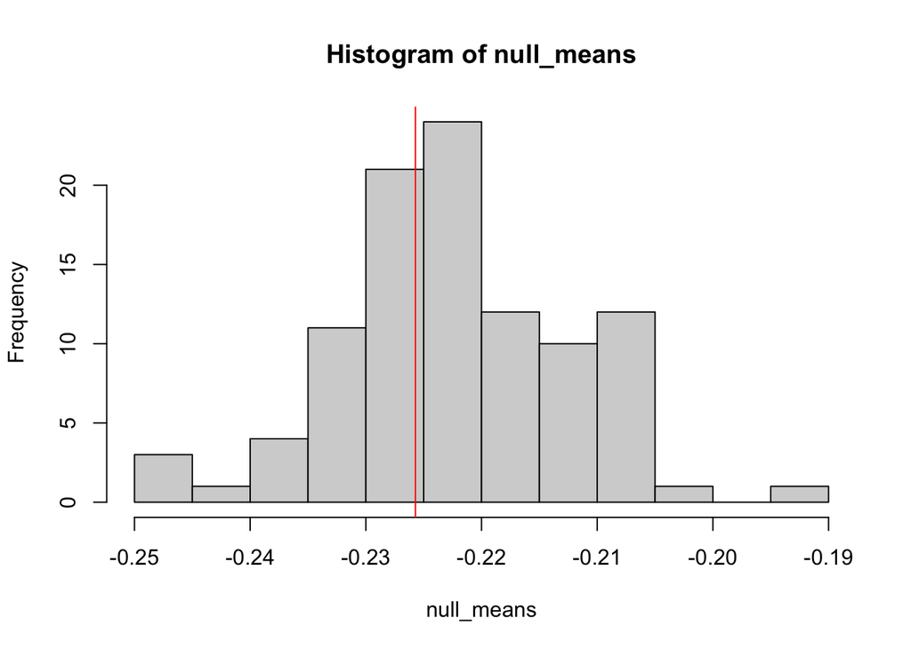

```r
hist(null_means); abline(v = observed_mean, col = "red")
```

```r
leaving_one_out_results <- map_dfr(subjects, function(current_subject) {
  subject_data <- valid_rows %>% filter(subject == current_subject)
  idx <- cbind(subject_data$previous_idx, subject_data$current_idx)
  others <- setdiff(names(matrix_list), toupper(current_subject))

  sims <- vapply(others, function(donor_id) matrix_list[[donor_id]][idx], numeric(nrow(subject_data)))
  leave_one_out_mean <- rowMeans(sims)

  tibble(subject = current_subject,
         own_correlation = cor(subject_data$euclidean_distance,
                               subject_data$Pairwise_Indv_Similarity),
         leaving_one_out_correlation = cor(subject_data$euclidean_distance,
                               leave_one_out_mean),
         general_correlation = cor(subject_data$euclidean_distance,
                               subject_data$Semantic_Similarity))
})
```

```r
leaving_one_out_results %>%
  summarise(across(c(own_correlation, leaving_one_out_correlation, general_correlation), list(mean = mean, median = median)))
```

```
## # A tibble: 1 × 6
##   own_correlation_mean own_correlation_median leaving_one_out_correlation_mean
##                  <dbl>                  <dbl>                            <dbl>
## 1               -0.226                 -0.224                           -0.285
## # ℹ 3 more variables: leaving_one_out_correlation_median <dbl>,
## #   general_correlation_mean <dbl>, general_correlation_median <dbl>
```

```r
t.test(leaving_one_out_results$own_correlation, leaving_one_out_results$leaving_one_out_correlation, paired = TRUE)
```

```
##
##  Paired t-test
##
## data:  leaving_one_out_results$own_correlation and leaving_one_out_results$leaving_one_out_correlation
## t = 5.5851, df = 80, p-value = 3.11e-07
## alternative hypothesis: true mean difference is not equal to 0
## 95 percent confidence interval:
##  0.03815850 0.08040434
## sample estimates:
## mean difference
##      0.05928142
```

```r
t.test(leaving_one_out_results$leaving_one_out_correlation, leaving_one_out_results$general_correlation, paired = TRUE)
```

```
##
##  Paired t-test
##
## data:  leaving_one_out_results$leaving_one_out_correlation and leaving_one_out_results$general_correlation
## t = 8.7349, df = 80, p-value = 2.916e-13
## alternative hypothesis: true mean difference is not equal to 0
## 95 percent confidence interval:
##  0.1032768 0.1642203
## sample estimates:
## mean difference
##       0.1337485
```

```r
set.seed(2026)
min_pairs <- 5
safe_to_correlate <- function(x, y) if (sd(x) == 0 || sd(y) == 0) NA_real_ else cor(x, y)

domain_cells <- map(subjects, function(current_subject) {
  subject_data <- valid_rows %>% filter(subject == current_subject)
  idx <- cbind(subject_data$previous_idx, subject_data$current_idx)
  others <- setdiff(names(matrix_list), toupper(current_subject))
  donors <- sample(others, num_permutation)

  donor_similarities <- vapply(donors, function(id) matrix_list[[id]][idx], numeric(nrow(subject_data)))
  leave_one_out_mean <- rowMeans(vapply(others, function(id) matrix_list[[id]][idx], numeric(nrow(subject_data))))

  map(unique(subject_data$domain), function(dom) {
    rows <- which(subject_data$domain == dom)
    if (length(rows) < min_pairs) return(NULL)
    distance <- subject_data$euclidean_distance[rows]
    own_correlation <- safe_to_correlate(distance, subject_data$Pairwise_Indv_Similarity[rows])
    if (is.na(own_correlation)) return(NULL)
    permutation_correlation <- apply(donor_similarities[rows, , drop = FALSE], 2, function(v) safe_to_correlate(distance, v))
    list(summary = tibble(subject = current_subject,
                          domain = dom,
                          num_pairs = length(rows),
                          own_correlation = own_correlation,
                          permutation_mean = mean(permutation_correlation, na.rm = TRUE),
                          leave_one_out_correlation = safe_to_correlate(distance, leave_one_out_mean[rows]),
                          general_correlation = safe_to_correlate(distance, subject_data$Semantic_Similarity[rows])),
         permutation_correlation = permutation_correlation)
  }) %>% compact()
}) %>% list_flatten()

domain_summary <- map_dfr(domain_cells, "summary") %>% drop_na()
```

```r
count(domain_summary, domain)
```

```
## # A tibble: 5 × 2
##   domain             n
##   <chr>          <int>
## 1 animals           80
## 2 authors           35
## 3 college_majors    81
## 4 musicians         57
## 5 sportspersons     39
```

```r
domain_summary %>%
  group_by(domain) %>%
  summarise(
    own_v_swap_difference = mean(own_correlation - permutation_mean),
    own_v_swap_p = t.test(own_correlation, permutation_mean, paired = TRUE)$p.value,

    own_v_loo_difference = mean(own_correlation - leave_one_out_correlation),
    own_v_loo_p = t.test(own_correlation, leave_one_out_correlation, paired = TRUE)$p.value,

    own_v_general_difference = mean(own_correlation - general_correlation),
    own_v_general_p = t.test(own_correlation, general_correlation, paired = TRUE)$p.value,

    loo_v_general_p = t.test(leave_one_out_correlation, general_correlation, paired = TRUE)$p.value
  )
```

```
## # A tibble: 5 × 8
##   domain     own_v_swap_difference own_v_swap_p own_v_loo_difference own_v_loo_p
##   <chr>                      <dbl>        <dbl>                <dbl>       <dbl>
## 1 animals                  0.00573        0.743               0.0944  0.00000156
## 2 authors                 -0.0977         0.199               0.165   0.113
## 3 college_m…              -0.0246         0.249               0.0572  0.0104
## 4 musicians               -0.0428         0.223               0.190   0.0000832
## 5 sportsper…              -0.0149         0.760               0.189   0.000567
## # ℹ 3 more variables: own_v_general_difference <dbl>, own_v_general_p <dbl>,
## #   loo_v_general_p <dbl>
```

```r
compare_correlations <- function(data, ..., min_n = 5) {
  data %>%
    group_by(...) %>%
    filter(n() >= min_n,
           n_distinct(euclidean_distance) >= 2,
           n_distinct(Semantic_Similarity) >= 2,
           n_distinct(Pairwise_Indv_Similarity) >= 2) %>%
    summarise(num_pairs = n(), #more negative r = stronger negative distance relation
            general_semantic_cor = cor(euclidean_distance, Semantic_Similarity),
            individual_semantic_cor = cor(euclidean_distance, Pairwise_Indv_Similarity),
            individual_sub_general = individual_semantic_cor - general_semantic_cor,
            .groups = "drop")
}

#correlations
general_semantic_correlation <- cor(
  valid_rows$euclidean_distance,
  valid_rows$Semantic_Similarity
  )

individual_semantic_correlation <- cor(
  valid_rows$euclidean_distance,
  valid_rows$Pairwise_Indv_Similarity
  )

cat(sprintf("Euclidean Distance vs General Semantic Similarity: %.3f\n",
            general_semantic_correlation
            ))
```

```
## Euclidean Distance vs General Semantic Similarity: -0.392
```

```r
cat(sprintf("Euclidean Distance vs Individual Semantic Similarity: %.3f\n",
            individual_semantic_correlation
            ))
```

```
## Euclidean Distance vs Individual Semantic Similarity: -0.218
```

```r
#r^2
correlation_r2 <- tibble(measure = c("General", "Individual"),
                         r = c(general_semantic_correlation, individual_semantic_correlation),
                         r_squared = c(general_semantic_correlation, individual_semantic_correlation)^2)
correlation_r2
```

```
## # A tibble: 2 × 3
##   measure         r r_squared
##   <chr>       <dbl>     <dbl>
## 1 General    -0.392    0.154
## 2 Individual -0.218    0.0473
```

Next, the same comparison as done previously was performed on the participant level. For each of the 81 participants remaining for analysis, the correlations between euclidean distance and the two semantic similarity measures was calculated. Then, the general semantic similarity was subtracted from the individual semantic similarity revealing that for 12 of the 81 participants, individual semantic similarity better correlated with their spatial distances in the SpAM task. For each of these participants, their SpAM arrangements were further examined and plotted in the cleaned_data folder under “spam_subject_layouts.pdf.”

```r
#one row per participant with two correlations + difference
subject_level_df <- compare_correlations(valid_rows, subject)

print(subject_level_df, n = Inf)
```

```
## # A tibble: 81 × 5
##    subject  num_pairs general_semantic_cor individual_semantic_cor
##    <chr>        <int>                <dbl>                   <dbl>
##  1 00K73X1D        48              -0.322                -0.266
##  2 0GMT2ITP        75              -0.423                -0.369
##  3 0L28O7LJ        60              -0.437                -0.224
##  4 0QPSDFM3        76              -0.488                -0.278
##  5 18HXK612        57              -0.355                -0.365
##  6 2BD455O0        88              -0.538                -0.154
##  7 37UDZTHY        62              -0.476                 0.0423
##  8 3YX63NZD        62              -0.496                -0.212
##  9 40SNDKQR        64              -0.366                -0.120
## 10 476LZI3N        32              -0.416                -0.434
## 11 4CA4DFWP        78              -0.540                -0.352
## 12 56M8U5A5        60              -0.319                -0.222
```

[output cut: 70 more lines]

```r
write_csv(subject_level_df, file.path(data_location, "cleaned_data", "subject_level_correlations.csv"))

#extract all participants whos indv semantic similarity outperformed general semantic similarity
mean(subject_level_df$individual_sub_general < 0, na.rm = TRUE)
```

```
## [1] 0.1481481
```

```r
print(summary(subject_level_df$individual_sub_general))
```

```
##     Min.  1st Qu.   Median     Mean  3rd Qu.     Max.
## -0.11563  0.06439  0.18815  0.19303  0.29475  0.56146
```

```r
#extracts subjects whos individual measure won
subjects_to_plot <- subject_level_df %>%
  filter(!is.na(individual_sub_general), individual_sub_general < 0) %>%
  pull(subject) %>%
  as.character %>%
  unique()

spam_subjects <- spatial_distances %>%
  mutate(subject = as.character(subject)) %>%
      filter(subject %in% subjects_to_plot)
```

```r
spam_layout_plot <- spam_subjects %>%
  group_by(subject, domain) %>%
  group_split() %>%
  map(function(subj) {
    subject_id <- unique(subj$subject)
    domain_name <- unique(as.character(subj$domain))

    ggplot(subj, aes(x = x, y = y)) +
      geom_point(size = 2.5, alpha = 0.8) +
      geom_text_repel(aes(label = word),
                      size = 3,
                      max.overlaps = Inf) +
      coord_equal() +
      labs(title = paste(subject_id, "-", domain_name),
           x = "x", y = "y") + theme_minimal()
  })

spam_combined_plots <- wrap_plots(spam_layout_plot, ncol = 2)

ggsave(filename = file.path(data_location, "cleaned_data", "spam_subject_layouts.pdf"),
       plot = spam_combined_plots, width = 14, height = max(10, 4 * ceiling(length(spam_layout_plot) / 2)), limitsize = FALSE)
```

This relationship was then examined at the domain level, for each participant.

```r
#repeat of prior analysis for each participant per domain
subject_domain_df <- compare_correlations(valid_rows, subject, domain)

print(subject_domain_df, n = Inf)
```

```
## # A tibble: 292 × 6
##     subject  domain        num_pairs general_semantic_cor individual_semantic_…¹
##     <chr>    <chr>             <int>                <dbl>                  <dbl>
##   1 00K73X1D animals              16              -0.436                -0.202
##   2 00K73X1D authors               5               0.924                -0.986
##   3 00K73X1D college_majo…        15              -0.821                -0.506
##   4 00K73X1D musicians             7               0.190                -0.604
##   5 00K73X1D sportspersons         5              -0.636                 0.246
##   6 0GMT2ITP animals              32              -0.557                -0.337
##   7 0GMT2ITP college_majo…        15              -0.583                -0.712
##   8 0GMT2ITP musicians            11              -0.247                -0.309
##   9 0GMT2ITP sportspersons        13              -0.190                -0.396
##  10 0L28O7LJ animals              23              -0.638                -0.347
##  11 0L28O7LJ authors               7               0.218                -0.0699
##  12 0L28O7LJ college_majo…        16              -0.295                -0.520
```

[output cut: 282 more lines]

```r
write_csv(subject_domain_df, file.path(data_location, "cleaned_data", "subject_domain_level_correlations.csv"))
```

```r
individual_level_sim_win <- subject_level_df %>%
  filter(individual_sub_general < 0) %>%
  pull(subject)

#in winners, how many win in each domain
domain_individual_level_win <- subject_domain_df %>%
  filter(subject %in% individual_level_sim_win) %>%
  group_by(domain) %>%
  summarise(
    num_negative = sum(individual_sub_general < 0),
    num_subject = n(),
    .groups = "drop"
  )

print(domain_individual_level_win)
```

```
## # A tibble: 5 × 3
##   domain         num_negative num_subject
##   <chr>                 <int>       <int>
## 1 animals                   1          11
## 2 authors                   5           6
## 3 college_majors            6          12
## 4 musicians                 4          11
## 5 sportspersons             1           7
```

```r
domain_subject_win <- subject_domain_df %>%
  filter(subject %in% individual_level_sim_win, individual_sub_general < 0) %>%
  select(subject, domain, individual_sub_general)

print(domain_subject_win, n = Inf)
```

```
## # A tibble: 17 × 3
##    subject  domain         individual_sub_general
##    <chr>    <chr>                           <dbl>
##  1 18HXK612 authors                       -0.535
##  2 476LZI3N college_majors                -0.0336
##  3 6PJDUW9O authors                       -0.196
##  4 6PJDUW9O musicians                     -0.256
##  5 FDULT82W college_majors                -0.0306
##  6 GNLFFB4P animals                       -0.539
##  7 GNLFFB4P authors                       -0.546
##  8 GNLFFB4P sportspersons                 -0.356
##  9 H6D2C4VR authors                       -0.114
## 10 H6D2C4VR musicians                     -0.120
## 11 IEOJ1IW3 musicians                     -0.705
## 12 NZ8ZTZHG college_majors                -0.166
## 13 YVQX6LL1 college_majors                -0.445
## 14 ZERL6DH6 authors                       -0.719
## 15 ZERL6DH6 college_majors                -0.169
## 16 ZYQ1C8LT college_majors                -0.0751
## 17 ZYQ1C8LT musicians                     -0.599
```

The analysis was then done at the domain level, exploring whether the individual vs general semantic model performed differently across domains. This revealed that the general semantic similarity measure had a stronger relation with spatial distance on the domains with the largest number of comparable pairs.

```r
domain_level_df <- compare_correlations(valid_rows, domain, min_n = 0)

print(domain_level_df, n = Inf)
```

```
## # A tibble: 5 × 5
##   domain         num_pairs general_semantic_cor individual_semantic_cor
##   <chr>              <int>                <dbl>                   <dbl>
## 1 animals             1644               -0.464                  -0.212
## 2 authors              356               -0.309                  -0.141
## 3 college_majors      1149               -0.446                  -0.324
## 4 musicians            660               -0.265                  -0.106
## 5 sportspersons        484               -0.340                  -0.127
## # ℹ 1 more variable: individual_sub_general <dbl>
```

## Fluency Analysis

Following the spatial distance analyses, fluency was analyzed in relation to both similarity measures. This analysis revealed the opposite pattern, as higher fluency was correlated with higher mean general semantic similarity (r = 0.438) and had a moderate positive correlation with individual semantic similarity (0.278).

```r
#collapses pair data into one row per word pair per person x domain, calculates each participant's mean general/individual semantic similarity within each domain
subject_mean_similarity <- valid_rows %>%
  mutate(subject = as.character(subject)) %>%
  group_by(subject, domain) %>%
  summarise(
    general_mean = mean(Semantic_Similarity, na.rm = TRUE),
    individual_mean = mean(Pairwise_Indv_Similarity, na.rm = TRUE),
    n_items = n(),
    .groups = "drop"
  )

#each participants fluency responses are counted and counts are joined with their mean semantic similarity
fluency <- read_csv(file.path(data_location, "raw_data", "organized_fluency.csv"),
                    show_col_types = FALSE) %>%
  mutate(subject = as.character(subject))

fluency_count <- fluency %>%
  group_by(subject, domain) %>%
  summarise(fluency_count = n(),
            .groups = "drop")


merged_similarity_fluency <- subject_mean_similarity %>%
  inner_join(fluency_count, by = c("subject", "domain")) %>%
  filter(n_items >= 2)

audit_rows("subject_mean_similarity x fluency_count", subject_mean_similarity, merged_similarity_fluency)
```

```
## # A tibble: 1 × 5
##   step                             rows_before rows_after rows_lost percent_kept
##   <chr>                                  <int>      <int>     <int>        <dbl>
## 1 subject_mean_similarity x fluen…         385        363        22         94.3
```

```r
#returns rows with either a similarity table but no fluency and vice versa
anti_join(subject_mean_similarity, fluency_count, by = c("subject", "domain"))
```

```
## # A tibble: 0 × 5
## # ℹ 5 variables: subject <chr>, domain <chr>, general_mean <dbl>,
## #   individual_mean <dbl>, n_items <int>
```

```r
anti_join(fluency_count, subject_mean_similarity, by = c("subject", "domain"))
```

```
## # A tibble: 165 × 3
##    subject  domain         fluency_count
##    <chr>    <chr>                  <int>
##  1 0MGC7F4K animals                   22
##  2 0MGC7F4K authors                    5
##  3 0MGC7F4K college_majors            15
##  4 0MGC7F4K musicians                  6
##  5 0MGC7F4K sportspersons              2
##  6 0PRAW6DO animals                   16
##  7 0PRAW6DO authors                    6
##  8 0PRAW6DO college_majors            12
##  9 0PRAW6DO musicians                  8
## 10 0PRAW6DO sportspersons              2
## # ℹ 155 more rows
```

```r
#checks loss from filter specifically
joined <- inner_join(subject_mean_similarity, fluency_count, by= c("subject", "domain"))
audit_rows("n_items >= 2 filter", joined, merged_similarity_fluency)
```

```
## # A tibble: 1 × 5
##   step                rows_before rows_after rows_lost percent_kept
##   <chr>                     <int>      <int>     <int>        <dbl>
## 1 n_items >= 2 filter         385        363        22         94.3
```

```r
general_sim_fluency_correlation <- cor(
  merged_similarity_fluency$fluency_count,
  merged_similarity_fluency$general_mean
)

individual_sim_fluency_correlation <- cor(
  merged_similarity_fluency$fluency_count,
  merged_similarity_fluency$individual_mean
)

cat(sprintf("Fluency count vs General similarity = %.3f\n", general_sim_fluency_correlation))
```

```
## Fluency count vs General similarity = 0.438
```

```r
cat(sprintf("Fluency count vs Individual similarity = %.3f\n", individual_sim_fluency_correlation))
```

```
## Fluency count vs Individual similarity = 0.278
```

```r
domain_fluency_correlations <- merged_similarity_fluency %>%
  group_by(domain) %>%
  filter(n() >= 5) %>%
  summarise(
    num_subjects = n(),
    general_cor = cor(fluency_count, general_mean),
    individual_cor = cor(fluency_count, individual_mean),
    difference = individual_cor - general_cor,
    .groups = "drop"
  )

print(domain_fluency_correlations, n = Inf)
```

```
## # A tibble: 5 × 5
##   domain         num_subjects general_cor individual_cor difference
##   <chr>                 <int>       <dbl>          <dbl>      <dbl>
## 1 animals                  81     0.250           0.135      -0.115
## 2 authors                  61     0.0195         -0.154      -0.174
## 3 college_majors           81     0.210          -0.0902     -0.300
## 4 musicians                73    -0.265          -0.132       0.133
## 5 sportspersons            67     0.00231         0.357       0.354
```

## SpAM Mixed Models

```r
model_data <- valid_rows %>%
  filter(is.finite(euclidean_distance),
         is.finite(Semantic_Similarity),
         is.finite(Pairwise_Indv_Similarity)) %>%
  mutate(subject = factor(subject), domain = factor(domain))

#general model including general semantic similarity, domain, and each subject acting as their own baseline, semantic similarity and domain as fixed effects with subject random intercept
general_semantic_model <- lmer (
  euclidean_distance ~ Semantic_Similarity + domain + (1 | subject),
  data = model_data, REML = TRUE
)

#individual model with same setup but individual semantic similarity
individual_semantic_model <- lmer (
  euclidean_distance ~ Pairwise_Indv_Similarity + domain + (1 | subject),
  data = model_data, REML = TRUE
)

summary(general_semantic_model)
```

```
## Linear mixed model fit by REML. t-tests use Satterthwaite's method [
## lmerModLmerTest]
## Formula: euclidean_distance ~ Semantic_Similarity + domain + (1 | subject)
##    Data: model_data
##
## REML criterion at convergence: -1123.9
##
## Scaled residuals:
##     Min      1Q  Median      3Q     Max
## -2.9590 -0.6865 -0.1814  0.5116  4.3812
##
## Random effects:
##  Groups   Name        Variance Std.Dev.
##  subject  (Intercept) 0.005177 0.07195
##  Residual             0.043056 0.20750
## Number of obs: 4293, groups:  subject, 81
##
## Fixed effects:
##                        Estimate Std. Error         df t value Pr(>|t|)
## (Intercept)           5.729e-01  1.391e-02  4.938e+02  41.186  < 2e-16 ***
## Semantic_Similarity  -6.782e-01  2.363e-02  4.241e+03 -28.697  < 2e-16 ***
## domainauthors        -2.135e-03  1.259e-02  4.249e+03  -0.170    0.865
## domaincollege_majors -1.270e-02  8.060e-03  4.233e+03  -1.576    0.115
## domainmusicians      -5.821e-02  1.011e-02  4.261e+03  -5.757 9.14e-09 ***
## domainsportspersons  -5.729e-02  1.113e-02  4.255e+03  -5.147 2.76e-07 ***
## ---
## Signif. codes:  0 '***' 0.001 '**' 0.01 '*' 0.05 '.' 0.1 ' ' 1
##
## Correlation of Fixed Effects:
##             (Intr) Smnt_S dmnthr dmncl_ dmnmsc
## Smntc_Smlrt -0.728
## domainathrs -0.296  0.199
## dmncllg_mjr -0.279  0.056  0.278
## domainmscns -0.378  0.257  0.280  0.349
## dmnsprtsprs -0.304  0.182  0.246  0.313  0.308
```

```r
summary(individual_semantic_model)
```

```
## Linear mixed model fit by REML. t-tests use Satterthwaite's method [
## lmerModLmerTest]
## Formula: euclidean_distance ~ Pairwise_Indv_Similarity + domain + (1 |
##     subject)
##    Data: model_data
##
## REML criterion at convergence: -600.2
##
## Scaled residuals:
##     Min      1Q  Median      3Q     Max
## -2.0641 -0.7478 -0.2326  0.5606  4.5327
##
## Random effects:
##  Groups   Name        Variance Std.Dev.
##  subject  (Intercept) 0.005775 0.07599
##  Residual             0.048663 0.22060
## Number of obs: 4293, groups:  subject, 81
##
## Fixed effects:
##                            Estimate Std. Error         df t value Pr(>|t|)
## (Intercept)               3.102e-01  1.026e-02  1.234e+02  30.248  < 2e-16 ***
## Pairwise_Indv_Similarity -4.333e-01  2.823e-02  4.266e+03 -15.348  < 2e-16 ***
## domainauthors             4.696e-02  1.320e-02  4.252e+03   3.558 0.000377 ***
## domaincollege_majors      3.165e-02  8.796e-03  4.231e+03   3.598 0.000324 ***
## domainmusicians           4.303e-03  1.042e-02  4.265e+03   0.413 0.679533
## domainsportspersons      -1.912e-02  1.171e-02  4.256e+03  -1.633 0.102439
## ---
## Signif. codes:  0 '***' 0.001 '**' 0.01 '*' 0.05 '.' 0.1 ' ' 1
##
## Correlation of Fixed Effects:
##             (Intr) Pr_I_S dmnthr dmncl_ dmnmsc
## Prws_Indv_S -0.177
## domainathrs -0.240  0.113
## dmncllg_mjr -0.294 -0.232  0.237
## domainmscns -0.297  0.076  0.248  0.319
## dmnsprtsprs -0.269  0.111  0.227  0.272  0.280
```

Marginal r^2, demonstrating the variance explained by fixed effects, and conditional r^2, demonstrating variance explained by the fixed effects and random participant inercepts were calculated and each revealed that the general model outperformed the indivudual.

```r
r2_general <- performance :: r2_nakagawa(general_semantic_model)
r2_individual <- performance :: r2_nakagawa(individual_semantic_model)

r2_comparison <- tibble(
  model = c("General", "Individual"),
  marginal_R2 = c(r2_general$R2_marginal, r2_individual$R2_marginal),
  conditional_R2 = c(r2_general$R2_conditional, r2_individual$R2_conditional)
)

print(r2_comparison)
```

```
## # A tibble: 2 × 3
##   model      marginal_R2 conditional_R2
##   <chr>            <dbl>          <dbl>
## 1 General         0.156           0.246
## 2 Individual      0.0552          0.155
```

Plots were made displaying fluency scores relation to both individual and general semantic similarity, and across domains with enough comparisons to be included.

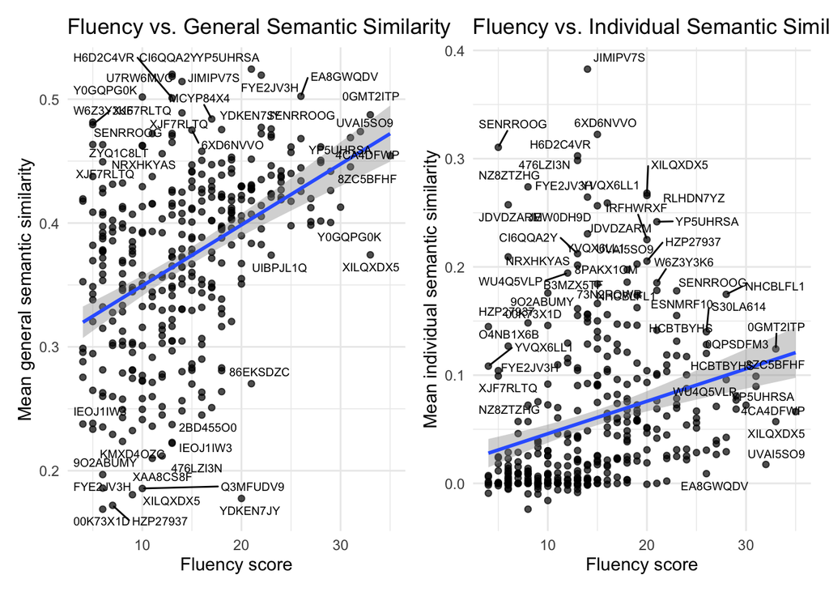

```r
fluency_plot_data <- merged_similarity_fluency %>%
  filter(
    n_items >= 2,
    is.finite(fluency_count),
    is.finite(general_mean),
    is.finite(individual_mean)
  )

plot_general <- ggplot(
  fluency_plot_data, aes(x = fluency_count, y = general_mean)
) +
  geom_point(alpha = 0.7) +
  geom_smooth(method = "lm", se = TRUE) +
  geom_text_repel(aes(label = subject), size = 2.5, max.overlaps = 15) +
  labs(
    title = "Fluency vs. General Semantic Similarity",
    x = "Fluency score",
    y = "Mean general semantic similarity"
  ) + theme_minimal()

plot_individual <- ggplot(
  fluency_plot_data, aes(x = fluency_count, y = individual_mean)
) +
  geom_point(alpha = 0.7) +
  geom_smooth(method = "lm", se = TRUE) +
  geom_text_repel(aes(label = subject), size = 2.5, max.overlaps = 15) +
  labs(
    title = "Fluency vs. Individual Semantic Similarity",
    x = "Fluency score",
    y = "Mean individual semantic similarity"
  ) + theme_minimal()

plot_general + plot_individual
```

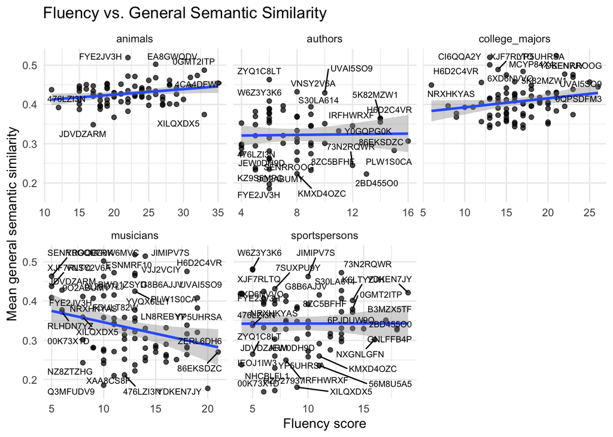

```r
plot_general + facet_wrap(~ domain, scales = "free_x")
```

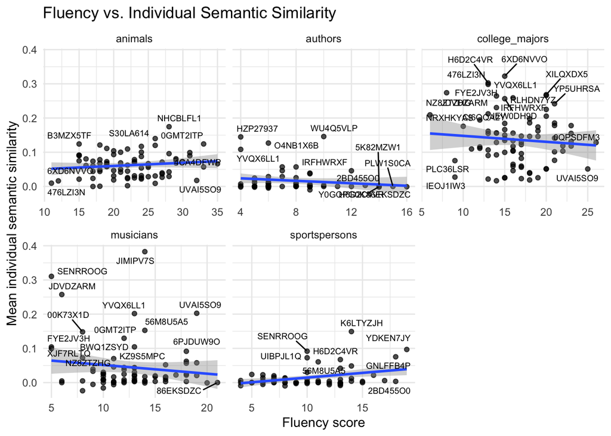

```r
plot_individual + facet_wrap(~ domain, scales = "free_x")
```